# Statistical inference with the GSS data

Somik Chowdhury

August 16, 2018

## Setup

### Load packages

```r
library(ggplot2)
library(dplyr)
library(statsr)
```

### Load data

Make sure your data and R Markdown files are in the same directory. When loaded your data file will be called `gss`. Delete this note when before you submit your work.

```r
load("~/R Coursera/gss.RData")
```

## Part 1: Data

The National Data Program for the Social Sciences has been conducted since 1972 by NORC at the University of Chicago, with the support of the National Science Foundation. This program has had two main goals: •To conduct basic scientific research on the structure and development of American society. •To distribute up-to-date, important, high-quality data to social scientists, students, policy makers, and others.

This research is carried out by a data collection program designed to both monitor social change within the United States and to compare the United States to other nations. Data on social change in the United States is collected as part of the GSS.

**Data Collection**

The vast majority of GSS data is obtained in face-to-face interviews. Computer-assisted personal interviewing (CAPI) began in the 2002 GSS. Under some conditions when it has proved difficult to arrange an in-person interview with a sampled respondent, GSS interviews may be conducted by telephone.

The target population of the GSS is adults (18+) living in households in the United States. From 1972 to 2004 it was further restricted to those able to do the survey in English. From 2006 to present it has included those able to do the survey in English or Spanish. Those unable to do the survey in either English or Spanish are out-of-scope. Residents of institutions and group quarters are out-of-scope. Those with mental and/or physical conditions that prevent them from doing the survey, but who live in households are part of the target population and in-scope. In the reinterviews those who have died, moved out of the United States, or who no longer live in a household have left the target population and are out-of-scope.

**Scopes of Inference**

As the survey is conducted by random sampling, the results from this project can be generalized to the entire US population. However, the statistical tests performed cannot provide causality relationships between the variables of interest.

**Scope of Biasness**

Since the survey is targeted only towards English and Spanish speakers, it does not take into account, the residents who do not speak English or Spanish.

## Part 2: Research question

**2.1 Research Question 1**

Does race of a Person affect the opinion of that person whether the Government should provide help to a person who is Black

Given the current Political scenario in US, it is interesting for me to know what the common citizens(Irrespective of Race) feel about helping the black population in the country.

**2.2 Research Question 2**

Does the class of a person affect the financial satisfaction index of an individual i.e. if a person is from upper class,does he/she feel more satisfied financially than a person who is from a lower class.

Being a salaried person myself, this question intrigues me whether satisfaction and wealth are correlated.

For this question, we are limiting the sample size to the most recent times. Hence we are taking the results for only 2012.

**2.3 Research Question 3**

Is there a significant change in Gun Ownership in United States, from the year 2000 to Year 2012.

Gun control is a hot topic in the United States at the moment and it is interesting for me to see if there is a significant change in gun wonership index from 2000 to 2012.

## Part 3: Exploratory data analysis

**Research Question 1**

Does race of a Person affect the opinion of that person whether the Government should provide help to a person who is Black

```r
gss_res1 <- gss %>% select(race,helpblk) %>% filter(!is.na(helpblk),!is.na(race))
head(gss_res1,5)
```

```
##    race              helpblk
## 1 White      Agree With Both
## 2 White No Special Treatment
## 3 White No Special Treatment
## 4 White       Govt Help Blks
## 5 White       Govt Help Blks
```

**Numerical Summary**

```r
gss_res1 %>% group_by(race) %>% summary(count=n())
```

```
##     race                       helpblk
##  White:15726   Govt Help Blks      :2688
##  Black: 3034   Agree With Both     :8540
##  Other: 1124   No Special Treatment:8656
```

**Extrapolation**

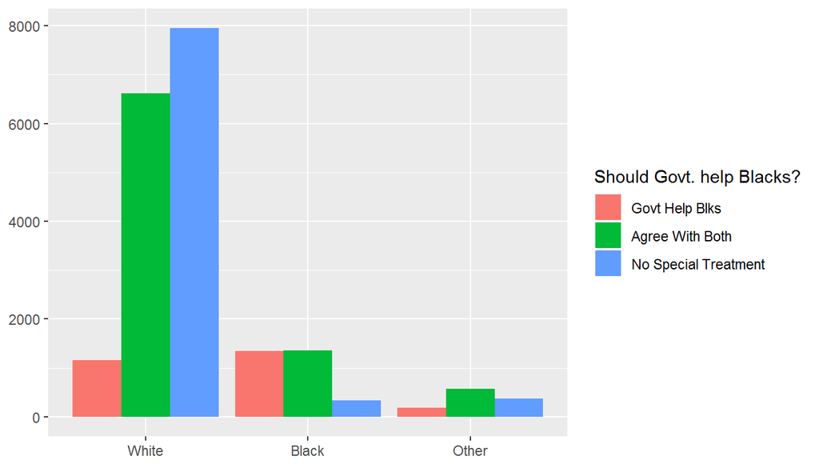

```r
plot_res1<-ggplot(gss_res1,aes(x=race))+geom_bar(aes(fill = helpblk),position = "dodge")+xlab(NULL)+ylab(NULL)+labs(fill="Should Govt. help Blacks?")
plot_res1
```

The plot shows that among the citizens who are white, Majority strongly feels that no special treatment should be given to people with Black ethnicity.

The black people on the other hand have answered exactly opposite of that with a divided majority on “Govt. should help black people” and “Agree with Both” while a small minority amongst blacks believe that No special treatment should be provided.

**Research Question 2**

Does the class of a person affect the financial satisfaction index of an individual

```r
gss_res_2<-gss %>% filter(year == "2012",!is.na(class),!is.na(satfin)) %>% select(class,satfin)
head(gss_res_2)
```

```
##          class         satfin
## 1  Upper Class      Satisfied
## 2 Middle Class      Satisfied
## 3 Middle Class   More Or Less
## 4  Upper Class      Satisfied
## 5  Lower Class Not At All Sat
## 6 Middle Class Not At All Sat
```

**Numerical Summary**

```r
gss_res_2 %>% group_by(class,satfin) %>% summary(count=n())
```

```
##            class                satfin
##  Lower Class  :200   Satisfied     :529
##  Working Class:850   More Or Less  :854
##  Middle Class :837   Not At All Sat:569
##  Upper Class  : 65
##  No Class     :  0
```

**Extrapolation**

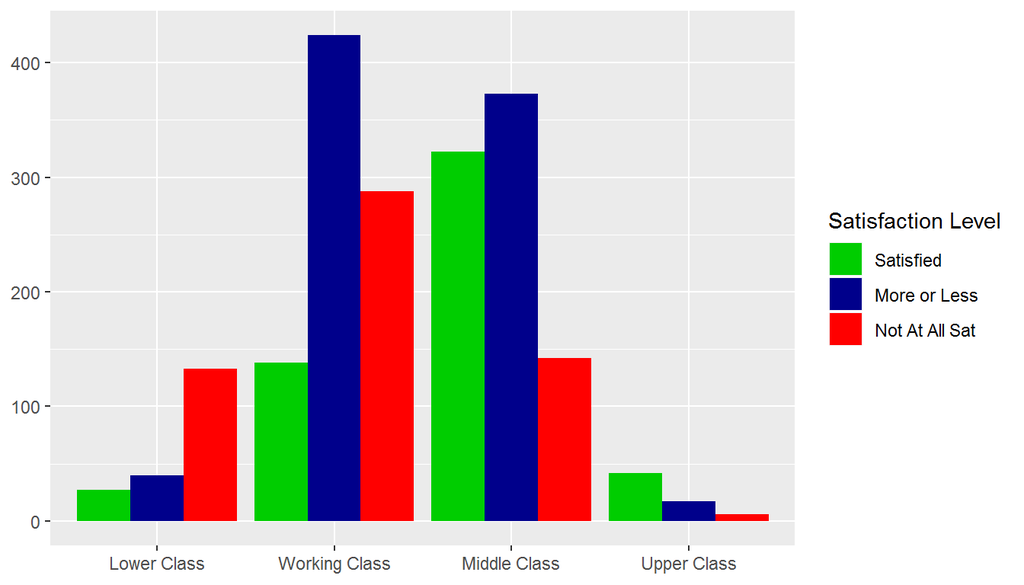

```r
plot_res2<-ggplot(gss_res_2,aes(x=class))+geom_bar(aes(fill = satfin),position = "dodge")+xlab(NULL)+ylab(NULL)+labs(fill="Satisfaction Level")+scale_fill_manual(labels = c("Satisfied","More or Less","Not At All Sat"),values = c("green3","Dark Blue","Red"))
plot_res2
```

**Research Question 3**

Is there a significant change in Gun Ownership in United States, from the year 2000 to Year 2012.

```r
gss_res_3<-gss %>% filter(year=="2000" | year=="2012",!is.na(owngun),owngun!="Refused") %>% select(year,owngun)
head(gss_res_3)
```

```
##   year owngun
## 1 2000    Yes
## 2 2000     No
## 3 2000     No
## 4 2000     No
## 5 2000     No
## 6 2000     No
```

**Numerical Summary**

```r
gss_res_3 %>% group_by(year) %>% summarize(count=n(),Yes_proportion = mean(owngun=="Yes"),No_proportion = mean(owngun=="No"))
```

```
## # A tibble: 2 x 4
##    year count Yes_proportion No_proportion
##   <int> <int>          <dbl>         <dbl>
## 1  2000  1834          0.329         0.671
## 2  2012  1281          0.343         0.657
```

**Extrapolation**

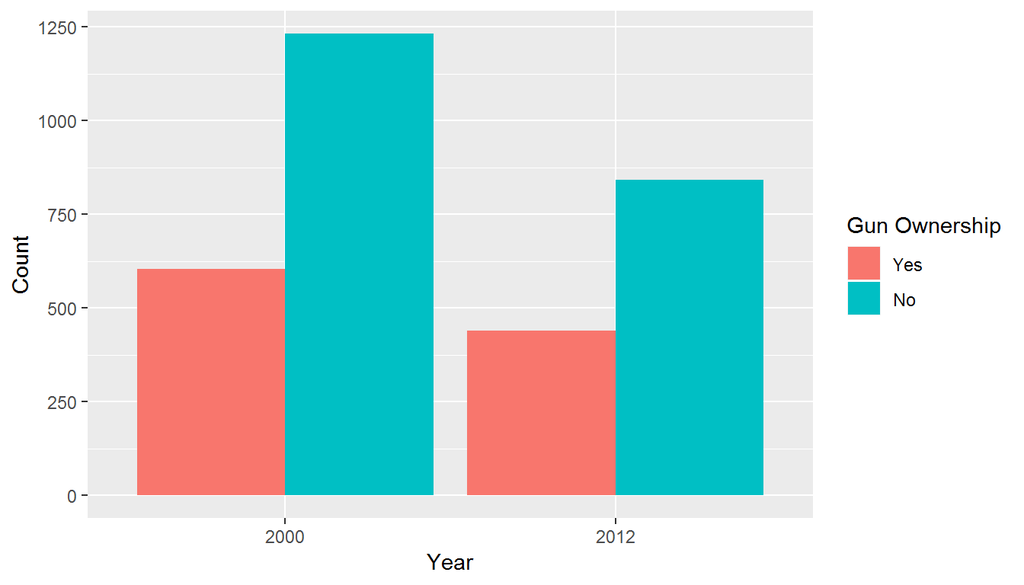

```r
ggplot(gss_res_3,aes(x=as.character(year)))+geom_bar(aes(fill = owngun),position = "dodge")+xlab("Year")+ylab("Count")+guides(fill=guide_legend(title="Gun Ownership"))
```

As per the extrapolation, it seems that the proportion of population not owning a gun has slightly decreased in the year 2012 when compared to 2000.

## Part 4: Inference

**Research Question 1**

Does race of a Person affect the opinion of that person whether the Government should provide help to a person who is Black.

Method used : Chi-Square Test for Independance,since we are trying to figure out if there is any dependance between two categorical variables.

Check Conditions : From the data, we can see all three conditions are satisfied

1. The sampling method is simple random sampling.
2. Both The variables under study are categorical
3. The expected value of the number of sample observations in each level of the variable is at least 5.

Since the sample variable has count>5, we should apply theoretical method for inference

Null Hypothesis H(o) : Race Does not Matter when it comes to whether Govt.should help blacks i.e. P(White)=P(Black)=P(Others)

Alternate Hypothesis H(A) : Race of a person affects whether the person believes that the Govt. should help blacks i.e P(White) ≠ P(Black) ≠ P(Others)

```r
gss_res1_mut<-gss_res1 %>% mutate(Help_Black_No = ifelse(helpblk=="No Special Treatment","Don't Help","Help/Both"))
```

```r
head(gss_res1_mut)
```

```
##    race              helpblk Help_Black_No
## 1 White      Agree With Both     Help/Both
## 2 White No Special Treatment    Don't Help
## 3 White No Special Treatment    Don't Help
## 4 White       Govt Help Blks     Help/Both
## 5 White       Govt Help Blks     Help/Both
## 6 White      Agree With Both     Help/Both
```

```r
inference(y=Help_Black_No,x=race,data = gss_res1_mut,statistic = c("proportion"),success = "Don't Help",method="theoretical",type="ht",alternative="greater")
```

```
## Response variable: categorical (2 levels)
## Explanatory variable: categorical (3 levels)
## Observed:
##        y
## x       Don't Help Help/Both
##   White       7953      7773
##   Black        332      2702
##   Other        371       753
##
## Expected:
##        y
## x       Don't Help Help/Both
##   White  6845.9191 8880.0809
##   Black  1320.7757 1713.2243
##   Other   489.3052  634.6948
##
## H0: race and Help_Black_No are independent
## HA: race and Help_Black_No are dependent
## chi_sq = 1678.601, df = 2, p_value = 0
```

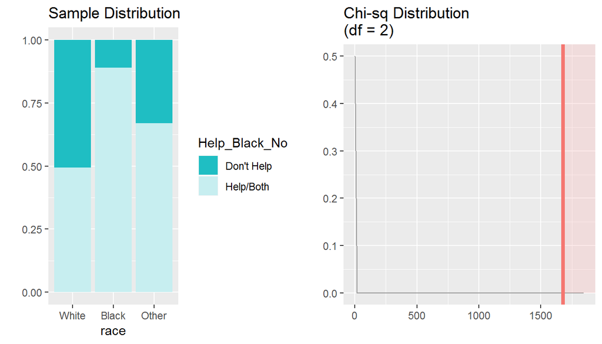

We can clearly see that the p-value is ~0, much lower than the significance level(0.05). So, we can safely reject the null hypothesis in favour of the Alternative i.e. There is a correlation between the race of an individual and his/her opinion on whether the Govt. should provide help to black people.

**Research Question 2**

Does the class of a person affect the financial satisfaction index of an individual

Method used : Chi-Square Test for Independance,since we are trying to figure out if there is any dependance between two categorical variables.

Check Conditions : From the data, we can see all three conditions are satisfied

1. The sampling method is simple random sampling.
2. Both The variables under study are categorical
3. The expected value of the number of sample observations in each level of the variable is at least 5.

Since the sample variable has count>5, we should apply theoretical method for inference

Null Hypothesis H(o) : There is no correlation between class of a person and his financial Satisfaction index i.e. P(lower)=P(working)=P(middle)=p(upper)

Alternate Hypothesis H(A) : Class of a person is a decisive factor when it comes to a person’s belief that he/she is financially satisfied i.e P(lower) ≠ P(working) ≠ P(middle)≠ P(Upper)

```
## Response variable: categorical (3 levels)
## Explanatory variable: categorical (5 levels)
## Observed:
##                y
## x               Satisfied More Or Less Not At All Sat
##   Lower Class          27           40            133
##   Working Class       138          424            288
##   Middle Class        322          373            142
##   Upper Class          42           17              6
##
## Expected:
##                y
## x               Satisfied More Or Less Not At All Sat
##   Lower Class    54.20082      87.5000       58.29918
##   Working Class 230.35348     371.8750      247.77152
##   Middle Class  226.83043     366.1875      243.98207
##   Upper Class    17.61527      28.4375       18.94723
##
## H0: class and satfin are independent
## HA: class and satfin are dependent
## chi_sq = 315.9045, df = 6, p_value = 0
```

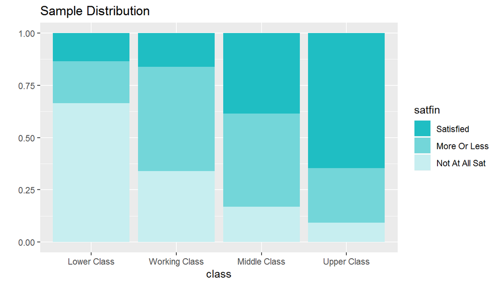

```r
inference(y=satfin,x=class,data = gss_res_2,statistic = c("proportion"),success = "Not At All Sat",method="theoretical",type="ht",alternative="greater",show_inf_plot = 0)
```

```
## Response variable: categorical (3 levels)
## Explanatory variable: categorical (5 levels)
## H0: class and satfin are independent
## HA: class and satfin are dependent
## chi_sq = 315.9045, df = 6, p_value = 0
```

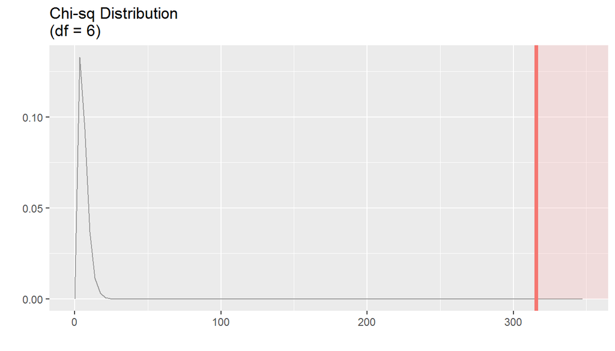

```r
inference(y=satfin,x=class,data = gss_res_2,statistic = c("proportion"),success = "Not At All Sat",method="theoretical",type="ht",alternative="greater",show_eda_plot=0,show_summ_stats=0)
```

We can clearly see that the p-value is very close to 0. Hence, it is quite clear that the null hypothesis should be rejected in favor of the alternate hypothesis i.e. the class of a person is a decisive factor in a person’s belief that he/she is financually satisfied.

**Research Question 3**

Is there a significant change in Gun Ownership in United States, from the year 2000 to Year 2012.

Check Conditions : From the data, we can see all three conditions are satisfied

1. The sampling method is simple random sampling.
2. Both The variables under study are categorical
3. The expected value of the number of sample observations in each level of the variable is at least 5.

Since the sample variable has count>5, we should apply theoretical method for inference

```r
inference(y=owngun, x=as.factor(year) ,data = gss_res_3, type = "ht", null = 0, statistic = "proportion", success = "Yes", method = "theoretical", alternative = "twosided", sig_level = 0.05, conf_level = 0.95)
```

```
## Response variable: categorical (2 levels, success: Yes)
## Explanatory variable: categorical (3 levels)
## n_2000 = 1834, p_hat_2000 = 0.3288
## n_2012 = 1281, p_hat_2012 = 0.3435
## H0: p_2000 =  p_2012
## HA: p_2000 != p_2012
## z = -0.855
## p_value = 0.3926
```

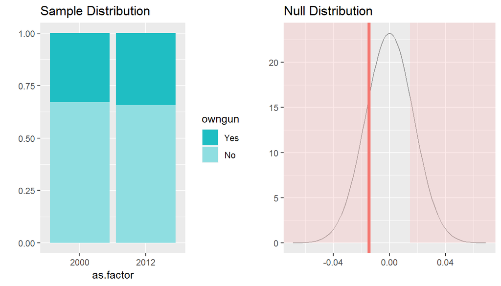

The p-value is 0.39 which is much higher than 0.05 significance level. Hence, we will fail to reject the NULL hypothesis in favor of the Alternate Hypothesis. i.e there is no convincing evidence which shows that there is a significant change in gun ownership in the years 2000 and 2012.